# Assignment 2: Differential Gene expression and Preliminary ORA

Wei Jin Luo

2025-03-01

# Introduction

Task: Take normalized expression data that was created in Assignment #1 and rank your genes according to differential expression. Once your list is ranked you will perform thresholded over-representation analysis to highlight dominant themes in your top set of genes.

## Background from A1

The data used in this anaysis was taken from the [GEO](https://www.ncbi.nlm.nih.gov/geo/) database and has the accession number GSE195585. The data is associated with this [paper](https://pmc.ncbi.nlm.nih.gov/articles/PMC9037237)(Centner C 2022), where the effects of collagen peptides (CP) combined with high-load resistance exercise on gene expression related to muscle protein synthesis was studied.

For A1, we performed the following: - Computed overview statistics to assess data quality for the control and test conditions in the dataset - Map the original Gene symbols to HUGO gene symbols and handle any missing symbols/ duplicates - Cleaned the data by removing any outliers - Applied normalization

The final dataset has HUGO gene symbols as row names, sample names as columns and the normalized expression for each gene for each respective sample

## Installing packages

We will use edgeR for the gene expression analysis

```r
# Check if Biocondutor is installed
if (!requireNamespace("BiocManager", quietly = TRUE))
    install.packages("BiocManager")

# Install knitr
if (!requireNamespace("knitr", quietly = TRUE))
    install.packages("knitr")

# Install edgeR
if (!requireNamespace("edgeR", quietly = TRUE))
    BiocManager::install("edgeR")

if (!requireNamespace("limma", quietly = TRUE))
  BiocManager::install("limma")

library(gprofiler2)
library(ggplot2)
library(ComplexHeatmap)
library(circlize)
```

# Differential Expression Analysis

First we need to load the normalized data from A1

```r
normalized_expression_data <- as.matrix(readRDS("normalized_expression_data.rds"))
```

## MDS Plot Grouped By Treatment

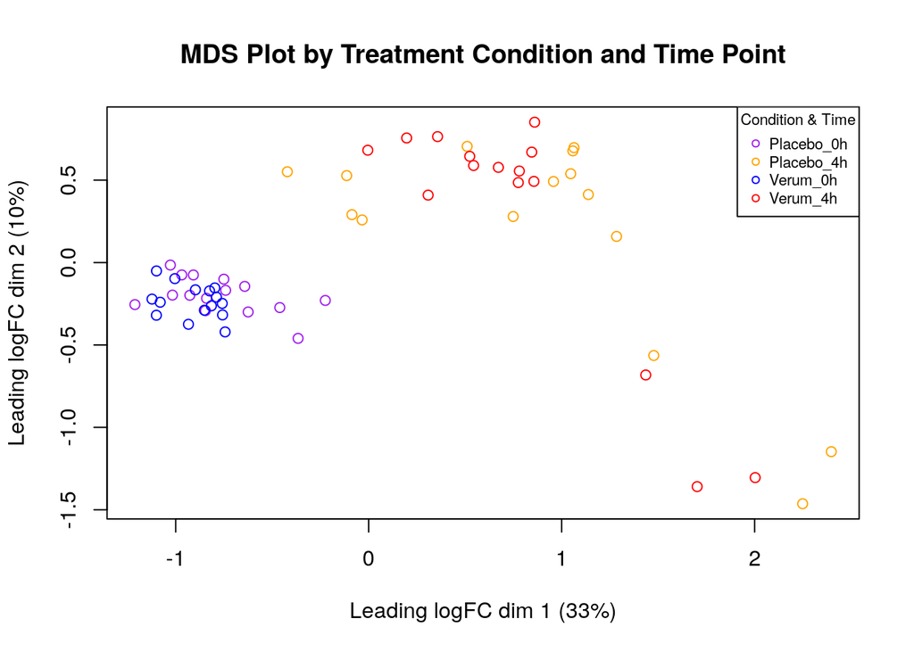

```r
# Extract sample names
sample_names <- colnames(normalized_expression_data)

# Identify treatment groups
treatment <- ifelse(grepl("^Placebo", sample_names), "Placebo", "Verum")

# Identify time points (0h vs. 4h)
time_point <- ifelse(grepl("_0h_", sample_names), "0h", "4h")

group <- factor(paste(treatment, time_point, sep = "_"))

d <- edgeR::DGEList(counts=normalized_expression_data, group = group)

limma::plotMDS(d,
        labels = NULL,
        pch = 1,
        top = 100,
        col = c("purple", "orange", "blue", "red")[factor(group)])  # Different colors for each condition

title(main = "MDS Plot by Treatment Condition and Time Point")

legend("topright",
       legend = levels(group),  # Legend labels (Placebo_0h, Placebo_4h, Verum_0h, Verum_4h)
       col = c("purple", "orange", "blue", "red"),
       pch = 1,
       cex = 0.7,
       title = "Condition & Time")
```

**Q1** For the differential expression analysis I decided to use the Quasi liklihood model which is good for more complicated models and RNASeq experiments. The p-value threshold of 0.05 was used to be consistent with the paper and it’s also the standard thresold for statistical significance.

**Q2** The Benjamini-Hochberg method was also used for multiple hypothesis correction as it was the method used in lecture and it has a good balance of specificity and sensitivity.

## Using edgeR

```r
sample_info <- data.frame(
    sample = colnames(d$counts),
    group = ifelse(grepl("^Placebo", colnames(d$counts)), "Placebo", "Verum"),
    time = ifelse(grepl("_0h", colnames(d$counts)), "0h", "4h")
)

# Convert to factors
sample_info$group <- factor(sample_info$group, levels = c("Placebo", "Verum"))  # Ensure correct reference level
sample_info$time <- factor(sample_info$time, levels = c("0h", "4h"))  # Ensure correct reference level

# Define model matrix with interaction term (group * time)
model_design <- model.matrix(~ group * time, data = sample_info)

d <- edgeR::estimateDisp(d, model_design)

fit <- edgeR::glmQLFit(d, model_design)
```

First compare placebo baseline vs placebo 4h

```r
# Compare Placebo 4h vs. Placebo 0h
results_Placebo <- edgeR::glmQLFTest(fit, contrast = c(0, 0, 1, 0))  # Placebo 4h vs. Placebo 0h
topfit_Placebo <- edgeR::topTags(results_Placebo, sort.by = "PValue", n = nrow(d$counts), adjust.method = "BH")
head(topfit_Placebo$table)
```

```
##                logFC    logCPM        F       PValue          FDR
## TNFRSF12A  4.0092752  5.520279 238.9571 1.269783e-22 1.641448e-18
## NR4A3      6.3648321  8.125660 224.6900 5.190557e-22 3.354916e-18
## PCMTD1-DT -0.9494006  4.425136 174.1246 1.898917e-19 6.181275e-16
## XIRP1      3.2533107 10.490683 173.6865 1.917024e-19 6.181275e-16
## NDRG3     -1.1129760  3.369080 174.7481 2.390839e-19 6.181275e-16
## NR1D1     -1.7811810  5.783256 168.1479 4.017575e-19 8.655865e-16
```

Number of genes that pass the p-value threshold of 0.05 for the placebo group

```r
length(which(topfit_Placebo$table$PValue < 0.05))
```

```
## [1] 4248
```

Number of genes that pass the correction for the placebo group

```r
length(which(topfit_Placebo$table$FDR < 0.05))
```

```
## [1] 2938
```

Next we can do the same thing for the collagen peptide treatment group

```r
# Compare Verum 4h vs. Verum 0h
results_Verum <- edgeR::glmQLFTest(fit, contrast = c(0, 0, 1, 1))  # Verum 4h vs. Verum 0h

# Extract top differentially expressed genes
topfit_Verum <- edgeR::topTags(results_Verum, sort.by = "PValue", n = nrow(d$counts), adjust.method = "BH")

head(topfit_Verum$table)
```

```
##                logFC    logCPM        F       PValue          FDR
## TNFRSF12A  4.6897378  5.520279 282.7295 2.054531e-24 2.655893e-20
## NR4A3      7.1386405  8.125660 225.9550 4.538798e-22 2.933652e-18
## XIRP1      3.6199096 10.490683 207.2897 3.242600e-21 1.397236e-17
## NDRG3     -1.1758660  3.369080 198.4877 1.336988e-20 4.320812e-17
## PCMTD1-DT -0.9887243  4.425136 191.9877 2.044559e-20 5.286002e-17
## DBP       -1.4428731  4.636488 183.0698 6.101455e-20 1.314559e-16
```

Number of genes that pass the p-value threshold of 0.05 for the collagen peptide treatment group

```r
length(which(topfit_Verum$table$PValue < 0.05))
```

```
## [1] 4818
```

Number of genes that pass the correction for the treatment group

```r
length(which(topfit_Verum$table$FDR < 0.05))
```

```
## [1] 3380
```

We can see that at the 4 hour timepoint, CP group shows a stronger transcriptional response at the 4-hour time point, with more DE genes passing both p-value and BH thresholds compared to the Placebo group.

This suggests that CP supplementation has a broader impact on gene expression, potentially affecting more biological pathways or processes. Which is consistent with the findings in the paper

# Plotting (Q3)

## Plotting with MA Plot with genes of interest highlighted

[figure not shown]

```r
# Create an MA plot for Placebo 4h vs. 0h
ma_data <- topfit_Placebo$table
ma_data$AverageExpression <- rowMeans(d$counts[rownames(ma_data), ])
ma_data$Significant <- ifelse(ma_data$FDR < 0.05 & abs(ma_data$logFC) > 1, "Significant", "Not Significant")

# Highlight genes of interest (e.g., top 10 most significant genes)
ma_data$GeneOfInterest <- ifelse(rownames(ma_data) %in% rownames(ma_data)[1:10], "Yes", "No")

ggplot(ma_data, aes(x = AverageExpression, y = logFC, color = Significant, shape = GeneOfInterest, size = GeneOfInterest)) +
  geom_point(alpha = 0.6) +
  scale_color_manual(values = c("Not Significant" = "gray", "Significant" = "red")) +
  scale_shape_manual(values = c("No" = 16, "Yes" = 17)) +  # Use triangles for genes of interest
  scale_size_manual(values = c("No" = 2, "Yes" = 5)) + # Also make them larger
  theme_minimal() +
  labs(title = "MA Plot: Placebo 4h vs. 0h",
       x = "Average Expression (log2)",
       y = "Log2 Fold Change",
       color = "Significant",
       shape = "Gene of Interest") +
  geom_hline(yintercept = 0, linetype = "dashed", color = "black")  # Add a horizontal line at logFC = 0
```

[figure not shown]

```r
# Create an MA plot for Placebo 4h vs. 0h
ma_data <- topfit_Verum$table
ma_data$AverageExpression <- rowMeans(d$counts[rownames(ma_data), ])
ma_data$Significant <- ifelse(ma_data$FDR < 0.05 & abs(ma_data$logFC) > 1, "Significant", "Not Significant")

ma_data$GeneOfInterest <- ifelse(rownames(ma_data) %in% rownames(ma_data)[1:10], "Yes", "No")

ggplot(ma_data, aes(x = AverageExpression, y = logFC, color = Significant, shape = GeneOfInterest, size = GeneOfInterest)) +
  geom_point(alpha = 0.6) +
  scale_color_manual(values = c("Not Significant" = "gray", "Significant" = "red")) +
  scale_shape_manual(values = c("No" = 16, "Yes" = 17)) +  # Use triangles for genes of interest
  scale_size_manual(values = c("No" = 2, "Yes" = 5)) + # Also make them larger
  theme_minimal() +
  labs(title = "MA Plot: Collagen Peptide Treatment 4h vs. 0h",
       x = "Average Expression (log2)",
       y = "Log2 Fold Change",
       color = "Significant",
       shape = "Gene of Interest") +
  geom_hline(yintercept = 0, linetype = "dashed", color = "black")
```

## Plotting with Volcano Plot

Creating a volcano plot for the placebo group

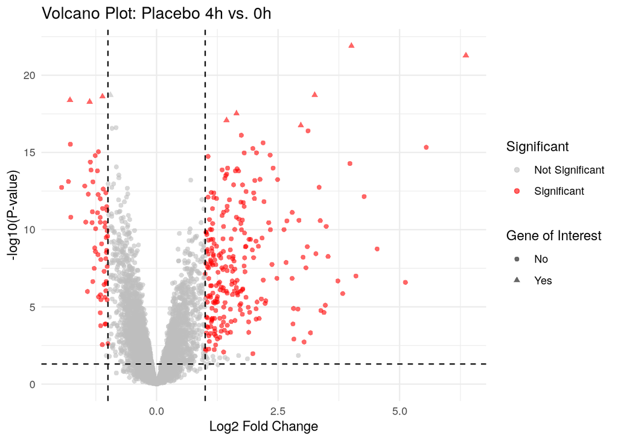

```r
# Create a volcano plot for Verum 4h vs. 0h
volcano_data <- topfit_Placebo$table
volcano_data$Significant <- ifelse(volcano_data$FDR < 0.05 & abs(volcano_data$logFC) > 1, "Significant", "Not Significant")

volcano_data$GeneOfInterest <- ifelse(rownames(volcano_data) %in% rownames(volcano_data)[1:10], "Yes", "No")

ggplot(volcano_data, aes(x = logFC, y = -log10(PValue), color = Significant, shape = GeneOfInterest)) +
  geom_point(alpha = 0.6) +
  scale_color_manual(values = c("Not Significant" = "gray", "Significant" = "red")) +
  scale_shape_manual(values = c("No" = 16, "Yes" = 17)) +  # Use triangles for genes of interest
  theme_minimal() +
  labs(title = "Volcano Plot: Placebo 4h vs. 0h",
       x = "Log2 Fold Change",
       y = "-log10(P-value)",
       color = "Significant",
       shape = "Gene of Interest") +
  geom_vline(xintercept = c(-1, 1), linetype = "dashed", color = "black") +
  geom_hline(yintercept = -log10(0.05), linetype = "dashed", color = "black")
```

Creating a volcano plot for the treatment group

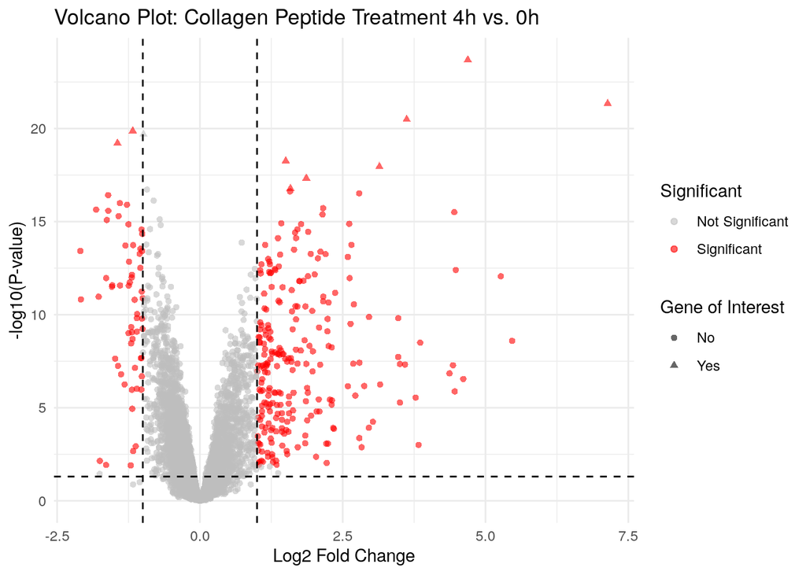

```r
# Create a volcano plot for Treatment 4h vs. 0h
volcano_data <- topfit_Verum$table
volcano_data$Significant <- ifelse(volcano_data$FDR < 0.05 & abs(volcano_data$logFC) > 1, "Significant", "Not Significant")

volcano_data$GeneOfInterest <- ifelse(rownames(volcano_data) %in% rownames(volcano_data)[1:10], "Yes", "No")

ggplot(volcano_data, aes(x = logFC, y = -log10(PValue), color = Significant, shape = GeneOfInterest)) +
  geom_point(alpha = 0.6) +
  scale_color_manual(values = c("Not Significant" = "gray", "Significant" = "red")) +
  scale_shape_manual(values = c("No" = 16, "Yes" = 17)) +
  theme_minimal() +
  labs(title = "Volcano Plot: Collagen Peptide Treatment 4h vs. 0h",
       x = "Log2 Fold Change",
       y = "-log10(P-value)",
       color = "Significant",
       shape = "Gene of Interest") +
  geom_vline(xintercept = c(-1, 1), linetype = "dashed", color = "black") +
  geom_hline(yintercept = -log10(0.05), linetype = "dashed", color = "black")
```

## Heatmap

Next we can visualize the top hits with a heatmap

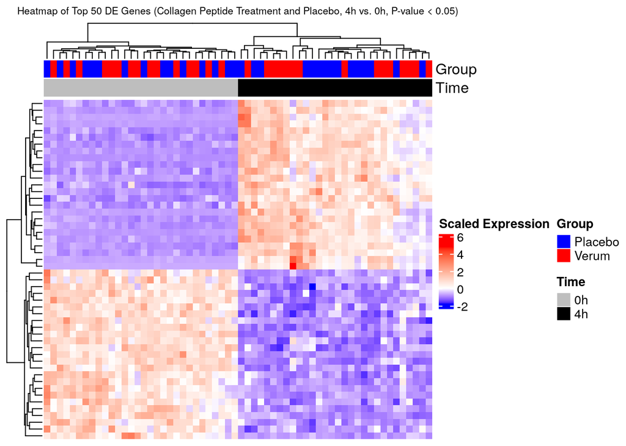

```r
verum_samples <- colnames(d$counts)[grepl("Verum", colnames(d$counts))]
placebo_samples <- colnames(d$counts)[grepl("Placebo", colnames(d$counts))]
all_samples <- c(verum_samples, placebo_samples)

heatmap_data <- d$counts[, all_samples]

top_genes <- rownames(topfit_Verum$table)[topfit_Verum$table$PValue < 0.05][1:50]
heatmap_data <- heatmap_data[top_genes, ]

heatmap_data_scaled <- t(scale(t(heatmap_data)))

if (min(heatmap_data_scaled) < 0) {
  heatmap_col <- colorRamp2(
    c(min(heatmap_data_scaled), 0, max(heatmap_data_scaled)),
    c("blue", "white", "red")
  )
} else {
  heatmap_col <- colorRamp2(
    range(heatmap_data_scaled),
    c("white", "red")
  )
}

annotation_df <- data.frame(
  Group = sample_info$group[colnames(d$counts) %in% all_samples],
  Time = sample_info$time[colnames(d$counts) %in% all_samples],
  stringsAsFactors = FALSE
)
rownames(annotation_df) <- colnames(heatmap_data_scaled)

annotation_colors <- list(
  Group = c(Placebo = "blue", Verum = "red"),
  Time = c(`0h` = "gray", `4h` = "black")
)

heatmap_annotation <- HeatmapAnnotation(
  df = annotation_df,
  col = annotation_colors
)

Heatmap(
  as.matrix(heatmap_data_scaled),
  col = heatmap_col,
  name = "Scaled Expression",
  cluster_rows = TRUE,
  cluster_columns = TRUE,
  show_row_dend = TRUE,
  show_column_dend = TRUE,
  show_row_names = FALSE,
  show_column_names = FALSE,
  show_heatmap_legend = TRUE,
  top_annotation = heatmap_annotation,
  column_title = "Heatmap of Top 50 DE Genes (Collagen Peptide Treatment and Placebo, 4h vs. 0h, P-value < 0.05)",
  column_title_gp = gpar(fontsize = 8)
)
```

# Thresholded over-representation analysis

**Q1** I will use the g:Profiler to run the ORA as this was the method I used when doing the homework assignment.

**Q2** The paper used KEGG for annotation data, but I also included Reactome and GO:BP so we can have more gene sets. The versions are as follows:

GO:BP – annotations: BioMart classes: releases/2024-10-27

KEGG – KEGG FTP Release 2024-01-22

REAC – annotations: BioMart classes: 2025-2-3

## Collagen Peptide Treatment Group

First we will do ORA with the collagen peptide treatment group

```r
# Extract significantly up-regulated genes (logFC > 0, FDR < 0.05)
up_genes <- rownames(topfit_Verum$table)[topfit_Verum$table$logFC > 0 & topfit_Verum$table$FDR < 0.05]

# Extract significantly down-regulated genes (logFC < 0, FDR < 0.05)
down_genes <- rownames(topfit_Verum$table)[topfit_Verum$table$logFC < 0 & topfit_Verum$table$FDR < 0.05]

# Extract all differentially expressed genes (FDR < 0.05)
all_genes <- rownames(topfit_Verum$table)[topfit_Verum$table$FDR < 0.05]

# Run ORA for up-regulated genes
ora_up <- gost(
  query = up_genes,
  organism = "hsapiens",
  correction_method = "fdr",
  exclude_iea = TRUE,
  ordered_query = FALSE,
  significant = FALSE,
  sources = c("GO", "KEGG", "REAC")
)

# Run ORA for down-regulated genes
ora_down <- gost(
  query = down_genes,
  organism = "hsapiens",
  correction_method = "fdr",
  exclude_iea = TRUE,
  ordered_query = FALSE,
  significant = FALSE,
  sources = c("GO", "KEGG", "REAC")
)

# Run ORA for all genes
ora_all <- gost(
  query = all_genes,
  organism = "hsapiens",
  correction_method = "fdr",
  exclude_iea = TRUE,
  ordered_query = FALSE,
  significant = FALSE,
  sources = c("GO", "KEGG", "REAC")
)
```

Gene sets in treatment group for upregulated genes before filtering: 10479

Gene sets in downregulated genes before filtering: 12071

Gene sets in all genes before filtering: 14557

Next we can filter the genes by term size:

```r
# Filter gene sets with a minimum of 10 genes and a maximum of 500 genes
ora_up_filtered <- ora_up$result[ora_up$result$term_size >= 10 & ora_up$result$term_size <= 500, ]
ora_down_filtered<- ora_down$result[ora_down$result$term_size >= 10 & ora_down$result$term_size <= 500, ]
ora_all_filtered <- ora_all$result[ora_all$result$term_size >= 10 & ora_all$result$term_size <= 500, ]
```

Gene sets in treatment group for upregulated genes after filtering: 7270

Gene sets in treatment group for downregulated genes after filtering: 7971

Gene sets in all genes after filtering: 8614

Finally we can visualize the top results in a table:

```r
# knitr
knitr::kable(ora_up_filtered[1:20, c("term_size", "term_name")],
      row.names = FALSE,
      caption = "**Top significant gene sets for upregulated genes for the Treatment Group**")
```

**Top significant gene sets for upregulated genes for the Treatment Group**

| term_size | term_name |
| --- | --- |
| 385 | positive regulation of apoptotic process |
| 401 | positive regulation of programmed cell death |
| 451 | cellular response to hormone stimulus |
| 463 | apoptotic signaling pathway |
| 408 | cellular response to lipid |
| 437 | response to organic cyclic compound |
| 345 | cellular response to organic cyclic compound |
| 434 | negative regulation of cell differentiation |
| 204 | regulation of phosphatidylinositol 3-kinase/protein kinase B signal transduction |
| 187 | cellular response to nutrient levels |
| 170 | extrinsic apoptotic signaling pathway |
| 235 | phosphatidylinositol 3-kinase/protein kinase B signal transduction |
| 480 | blood vessel development |
| 400 | angiogenesis |
| 447 | blood vessel morphogenesis |
| 121 | muscle cell proliferation |
| 113 | regulation of extrinsic apoptotic signaling pathway |
| 262 | response to nutrient levels |
| 175 | regulation of RNA splicing |
| 275 | regulation of apoptotic signaling pathway |

```r
knitr::kable(ora_down_filtered[1:20, c("term_size", "term_name")],
      row.names = FALSE,
      caption = "**Top significant gene sets for downregulated genes for the Treatment Group**")
```

**Top significant gene sets for downregulated genes for the Treatment Group**

| term_size | term_name |
| --- | --- |
| 15 | mRNA methylguanosine-cap decapping |
| 116 | phosphatidylinositol biosynthetic process |
| 10 | deadenylation-dependent decapping of nuclear-transcribed mRNA |
| 46 | microtubule nucleation |
| 136 | phosphatidylinositol metabolic process |
| 18 | RNA decapping |
| 42 | base-excision repair |
| 147 | DNA-templated DNA replication |
| 231 | DNA replication |
| 80 | myoblast differentiation |
| 435 | regulation of DNA metabolic process |
| 31 | nuclear-transcribed mRNA poly(A) tail shortening |
| 226 | glycerolipid biosynthetic process |
| 90 | regulation of fat cell differentiation |
| 48 | negative regulation of cold-induced thermogenesis |
| 22 | tertiary alcohol metabolic process |
| 228 | defense response to virus |
| 207 | regulation of DNA repair |
| 145 | fat cell differentiation |
| 68 | circadian regulation of gene expression |

```r
knitr::kable(ora_all_filtered[1:20, c("term_size", "term_name")],
      row.names = FALSE,
      caption = "**Top significant gene sets for all differentially expressed genes for the Treatment Group**")
```

**Top significant gene sets for all differentially expressed genes for the Treatment Group**

| term_size | term_name |
| --- | --- |
| 145 | fat cell differentiation |
| 90 | regulation of fat cell differentiation |
| 31 | nuclear-transcribed mRNA poly(A) tail shortening |
| 434 | negative regulation of cell differentiation |
| 80 | myoblast differentiation |
| 57 | nuclear-transcribed mRNA catabolic process, deadenylation-dependent decay |
| 68 | circadian regulation of gene expression |
| 226 | glycerolipid biosynthetic process |
| 178 | hormone-mediated signaling pathway |
| 152 | nuclear receptor-mediated signaling pathway |
| 218 | phospholipid biosynthetic process |
| 187 | cellular response to nutrient levels |
| 451 | cellular response to hormone stimulus |
| 104 | response to unfolded protein |
| 477 | positive regulation of catabolic process |
| 51 | positive regulation of fat cell differentiation |
| 414 | muscle structure development |
| 113 | nuclear-transcribed mRNA catabolic process |
| 66 | miRNA transcription |
| 78 | regulation of miRNA metabolic process |

## Placebo group

Now we will do the same thing for the placebo group

```r
# Extract significantly up-regulated genes (logFC > 0, FDR < 0.05)
up_genes <- rownames(topfit_Placebo$table)[topfit_Placebo$table$logFC > 0 & topfit_Placebo$table$FDR < 0.05]

# Extract significantly down-regulated genes (logFC < 0, FDR < 0.05)
down_genes <- rownames(topfit_Placebo$table)[topfit_Placebo$table$logFC < 0 & topfit_Placebo$table$FDR < 0.05]

# Extract all differentially expressed genes (FDR < 0.05)
all_genes <- rownames(topfit_Placebo$table)[topfit_Placebo$table$FDR < 0.05]

# Run ORA for up-regulated genes
ora_up_placebo <- gost(
  query = up_genes,
  organism = "hsapiens",
  correction_method = "fdr",
  exclude_iea = TRUE,
  ordered_query = FALSE,
  significant = FALSE,
  sources = c("GO", "KEGG", "REAC")
)

# Run ORA for down-regulated genes
ora_down_placebo <- gost(
  query = down_genes,
  organism = "hsapiens",
  correction_method = "fdr",
  exclude_iea = TRUE,
  ordered_query = FALSE,
  significant = FALSE,
  sources = c("GO", "KEGG", "REAC")
)

# Run ORA for all DE genes
ora_all_placebo <- gost(
  query = all_genes,
  organism = "hsapiens",
  correction_method = "fdr",
  exclude_iea = TRUE,
  ordered_query = FALSE,
  significant = FALSE,
  sources = c("GO", "KEGG", "REAC")
)
```

Gene sets in upregulated genes before filtering: 10245

Gene sets in downregulated genes before filtering: 11661

Gene sets in all genes before filtering: 14141

Filter genes by term size:

```r
# Filter gene sets with a minimum of 10 genes and a maximum of 500 genes
ora_up_placebo_filtered <- ora_up_placebo$result[ora_up_placebo$result$term_size >= 10 & ora_up_placebo$result$term_size <= 500, ]
ora_down_placebo_filtered<- ora_down_placebo$result[ora_down_placebo$result$term_size >= 10 & ora_down_placebo$result$term_size <= 500, ]
ora_all_placebo_filtered <- ora_all_placebo$result[ora_all_placebo$result$term_size >= 10 & ora_all_placebo$result$term_size <= 500, ]
```

Gene sets in upregulated genes after filtering: 7205

Gene sets in downregulated genes after filtering: 7838

Gene sets in all genes after filtering: 8557

Display results in table

```r
# knitr
knitr::kable(ora_up_placebo_filtered[1:50, c("term_size", "term_name")],
      row.names = FALSE,
      caption = "*Top significant gene sets for upregulated genes**")
```

*Top significant gene sets for upregulated genes**

| term_size | term_name |
| --- | --- |
| 463 | apoptotic signaling pathway |
| 385 | positive regulation of apoptotic process |
| 187 | cellular response to nutrient levels |
| 401 | positive regulation of programmed cell death |
| 170 | extrinsic apoptotic signaling pathway |
| 437 | response to organic cyclic compound |
| 451 | cellular response to hormone stimulus |
| 66 | miRNA transcription |
| 275 | regulation of apoptotic signaling pathway |
| 345 | cellular response to organic cyclic compound |
| 434 | negative regulation of cell differentiation |
| 262 | response to nutrient levels |
| 408 | cellular response to lipid |
| 244 | intrinsic apoptotic signaling pathway |
| 65 | regulation of miRNA transcription |
| 31 | ‘de novo’ post-translational protein folding |
| 145 | fat cell differentiation |
| 78 | regulation of miRNA metabolic process |
| 148 | signal transduction by p53 class mediator |
| 26 | chaperone cofactor-dependent protein refolding |
| 204 | regulation of phosphatidylinositol 3-kinase/protein kinase B signal transduction |
| 119 | response to topologically incorrect protein |
| 480 | blood vessel development |
| 175 | regulation of RNA splicing |
| 93 | miRNA metabolic process |
| 35 | ‘de novo’ protein folding |
| 104 | response to unfolded protein |
| 68 | circadian regulation of gene expression |
| 273 | regulation of mRNA metabolic process |
| 12 | response to activity |
| 138 | cellular response to starvation |
| 98 | regulation of mRNA splicing, via spliceosome |
| 447 | blood vessel morphogenesis |
| 63 | extrinsic apoptotic signaling pathway via death domain receptors |
| 235 | phosphatidylinositol 3-kinase/protein kinase B signal transduction |
| 25 | protein refolding |
| 400 | angiogenesis |
| 113 | regulation of extrinsic apoptotic signaling pathway |
| 40 | mesenchyme morphogenesis |
| 48 | positive regulation of miRNA transcription |
| 57 | positive regulation of miRNA metabolic process |
| 66 | chaperone-mediated protein folding |
| 159 | response to starvation |
| 315 | vesicle organization |
| 254 | ossification |
| 149 | hexose metabolic process |
| 34 | endocardial cushion morphogenesis |
| 150 | positive regulation of phosphatidylinositol 3-kinase/protein kinase B signal transduction |
| 162 | circadian rhythm |
| 140 | cellular response to insulin stimulus |

```r
knitr::kable(ora_down_placebo_filtered[1:50, c("term_size", "term_name")],
      row.names = FALSE,
      caption = "**Top significant gene set hits for downregulated genes**")
```

**Top significant gene set hits for downregulated genes**

| term_size | term_name |
| --- | --- |
| 228 | defense response to virus |
| 345 | Wnt signaling pathway |
| 257 | canonical Wnt signaling pathway |
| 165 | neuron projection guidance |
| 165 | axon guidance |
| 101 | regulation of ketone metabolic process |
| 152 | nuclear receptor-mediated signaling pathway |
| 116 | phosphatidylinositol biosynthetic process |
| 118 | negative regulation of canonical Wnt signaling pathway |
| 178 | hormone-mediated signaling pathway |
| 136 | phosphatidylinositol metabolic process |
| 48 | replication fork processing |
| 146 | negative regulation of Wnt signaling pathway |
| 147 | DNA-templated DNA replication |
| 243 | regulation of lipid metabolic process |
| 212 | regulation of canonical Wnt signaling pathway |
| 189 | glycerophospholipid biosynthetic process |
| 57 | DNA-templated DNA replication maintenance of fidelity |
| 107 | nuclear receptor-mediated steroid hormone signaling pathway |
| 18 | RNA decapping |
| 226 | glycerolipid biosynthetic process |
| 218 | phospholipid biosynthetic process |
| 302 | intracellular receptor signaling pathway |
| 269 | glycerophospholipid metabolic process |
| 109 | steroid hormone receptor signaling pathway |
| 140 | DNA biosynthetic process |
| 48 | regulation of neural precursor cell proliferation |
| 10 | deadenylation-dependent decapping of nuclear-transcribed mRNA |
| 334 | response to virus |
| 10 | negative regulation of receptor binding |
| 337 | glycerolipid metabolic process |
| 435 | regulation of DNA metabolic process |
| 277 | regulation of Wnt signaling pathway |
| 15 | mRNA methylguanosine-cap decapping |
| 80 | negative regulation of lipid metabolic process |
| 328 | phospholipid metabolic process |
| 67 | negative regulation of protein binding |
| 252 | positive regulation of cell projection organization |
| 82 | negative regulation of small molecule metabolic process |
| 90 | regulation of fat cell differentiation |
| 298 | double-strand break repair |
| 23 | positive regulation of cholesterol efflux |
| 29 | mismatch repair |
| 92 | cellular response to topologically incorrect protein |
| 49 | positive regulation of osteoblast differentiation |
| 148 | kidney development |
| 18 | hematopoietic stem cell proliferation |
| 466 | regulation of plasma membrane bounded cell projection organization |
| 36 | embryonic skeletal system morphogenesis |
| 71 | regulation of fatty acid metabolic process |

```r
knitr::kable(ora_all_placebo_filtered[1:50, c("term_size", "term_name")],
      row.names = FALSE,
      caption = "**Top significant gene set hits for all differentially expressed genes**")
```

**Top significant gene set hits for all differentially expressed genes**

| term_size | term_name |
| --- | --- |
| 101 | regulation of ketone metabolic process |
| 451 | cellular response to hormone stimulus |
| 145 | fat cell differentiation |
| 226 | glycerolipid biosynthetic process |
| 68 | circadian regulation of gene expression |
| 178 | hormone-mediated signaling pathway |
| 434 | negative regulation of cell differentiation |
| 218 | phospholipid biosynthetic process |
| 152 | nuclear receptor-mediated signaling pathway |
| 90 | regulation of fat cell differentiation |
| 66 | miRNA transcription |
| 189 | glycerophospholipid biosynthetic process |
| 119 | response to topologically incorrect protein |
| 152 | response to insulin |
| 65 | regulation of miRNA transcription |
| 104 | response to unfolded protein |
| 269 | glycerophospholipid metabolic process |
| 187 | cellular response to nutrient levels |
| 480 | blood vessel development |
| 140 | cellular response to insulin stimulus |
| 302 | intracellular receptor signaling pathway |
| 401 | positive regulation of programmed cell death |
| 236 | response to peptide hormone |
| 162 | circadian rhythm |
| 447 | blood vessel morphogenesis |
| 92 | cellular response to topologically incorrect protein |
| 243 | regulation of lipid metabolic process |
| 328 | phospholipid metabolic process |
| 71 | regulation of fatty acid metabolic process |
| 84 | insulin receptor signaling pathway |
| 116 | phosphatidylinositol biosynthetic process |
| 385 | positive regulation of apoptotic process |
| 136 | phosphatidylinositol metabolic process |
| 337 | glycerolipid metabolic process |
| 257 | canonical Wnt signaling pathway |
| 242 | regulation of small molecule metabolic process |
| 142 | cellular response to steroid hormone stimulus |
| 109 | steroid hormone receptor signaling pathway |
| 345 | cellular response to organic cyclic compound |
| 100 | positive regulation of endothelial cell migration |
| 82 | negative regulation of small molecule metabolic process |
| 78 | regulation of miRNA metabolic process |
| 199 | cellular response to peptide hormone stimulus |
| 184 | rhythmic process |
| 79 | cellular response to unfolded protein |
| 273 | regulation of mRNA metabolic process |
| 93 | miRNA metabolic process |
| 450 | positive regulation of cell migration |
| 107 | nuclear receptor-mediated steroid hormone signaling pathway |
| 80 | myoblast differentiation |

# Interpretation questions

1. Do the over-representation results support conclusions or mechanism discussed in the original paper?

Yes, the original paper identified 30 upregulated pathways, including:

7 endocrine-related pathways

5 signal transduction pathways

4 nervous system pathways

4 cellular community - eukaryotes pathways

2 immune system pathways

2 digestive system pathways

1 development pathway

1 cell motility pathway

1 amino acid metabolism pathway

1 signaling molecules and interaction pathway

1 circulatory system pathway

1 environmental adaptation pathway

A lot of the pathways that were upregulated in my top hits also align with the pathways that were identified by the authors, namely the upregulation of phosphatidylinositol 3-kinase/protein kinase B signal transduction which we see in my ORA results or the PI3K-Akt-Pathway, is heavily discussed in the paper.

2. Can you find evidence, i.e. publications, to support some of the results that you see. How does this evidence support your results.

Yes, we can already find papers that support that resistance training causes the upregulation of the PI3K-Akt-Pathway (Feng et al. 2022), which is a pathway known to be involved in muscle synthesis (Glass 2010). additionally, we see that in our significant gene sets, in the treatment group the PI3K-Akt-Pathway is significantly higher on the list (ranked by p-value), supporting that it is more significantly enriched in the treatment group compared to the placebo. This is also supported by literature (Oertzen-Hagemann et al. 2019)

# References

This analysis uses several R packages including `BiocManager` (Morgan and Ramos 2024), `edgeR` (Chen et al. 2024), `knitr` (Xie 2024), `ggplot2` (Wickham 2016), `limma` (Ritchie et al. 2015), `gprofiler2` (Kolberg et al. 2020), `ComplexHeatmap` (Gu, Eils, and Schlesner 2016), and `circlize` (Gu et al. 2014).

Centner C, Mallard A, Jerger S. 2022. “Supplementation of Specific Collagen Peptides Following High-Load Resistance Exercise Upregulates Gene Expression in Pathways Involved in Skeletal Muscle Signal Transduction.” *Front Physiol.* 13: 838004. https://doi.org/10.3389/fphys.2022.838004.

Chen, Yunshun, Lizhong Chen, Aaron T L Lun, Pedro Baldoni, and Gordon K Smyth. 2024. “edgeR 4.0: Powerful Differential Analysis of Sequencing Data with Expanded Functionality and Improved Support for Small Counts and Larger Datasets.” *bioRxiv*. https://doi.org/10.1101/2024.01.21.576131.

Feng, Li-Li, Bo-Wen Li, Yan Xi, Meng Cai, and Zhen Tian. 2022. “Aerobic Exercise and Resistance Exercise Alleviate Skeletal Muscle Atrophy Through IGF-1/IGF-1R-PI3K/Akt Pathway in Mice with Myocardial Infarction.” *American Journal of Physiology-Cell Physiology* 322 (2): C164–76. https://doi.org/10.1152/ajpcell.00344.2021.

Glass, David J. 2010. “PI3 Kinase Regulation of Skeletal Muscle Hypertrophy and Atrophy.” *Current Topics in Microbiology and Immunology* 346: 267–78. https://doi.org/10.1007/82_2010_78.

Gu, Zuguang, Roland Eils, and Matthias Schlesner. 2016. “Complex Heatmaps Reveal Patterns and Correlations in Multidimensional Genomic Data.” *Bioinformatics*. https://doi.org/10.1093/bioinformatics/btw313.

Gu, Zuguang, Lei Gu, Roland Eils, Matthias Schlesner, and Benedikt Brors. 2014. “Circlize Implements and Enhances Circular Visualization in r.” *Bioinformatics* 30: 2811–12.

Kolberg, Liis, Uku Raudvere, Ivan Kuzmin, Jaak Vilo, and Hedi Peterson. 2020. “Gprofiler2– an r Package for Gene List Functional Enrichment Analysis and Namespace Conversion Toolset g:profiler.” *F1000Research* 9 (ELIXIR) (709).

Morgan, Martin, and Marcel Ramos. 2024. *BiocManager: Access the Bioconductor Project Package Repository*. https://bioconductor.github.io/BiocManager/.

Oertzen-Hagemann, Victoria, Maik Kirmse, Bastian Eggers, Kerstin Pfeiffer, Katrin Marcus, Marco de Marées, Petra Platen, Falko Hildebrand, and Karsten Krüger. 2019. “Effects of 12 Weeks of Hypertrophy Resistance Exercise Training Combined with Collagen Peptide Supplementation on the Skeletal Muscle Proteome in Recreationally Active Men.” *Nutrients* 11 (5): 1072. https://doi.org/10.3390/nu11051072.

Ritchie, Matthew E, Belinda Phipson, Di Wu, Yifang Hu, Charity W Law, Wei Shi, and Gordon K Smyth. 2015. “limma Powers Differential Expression Analyses for RNA-Sequencing and Microarray Studies.” *Nucleic Acids Research* 43 (7): e47. https://doi.org/10.1093/nar/gkv007.

Wickham, Hadley. 2016. *Ggplot2: Elegant Graphics for Data Analysis*. Springer-Verlag New York. https://ggplot2.tidyverse.org.

Xie, Yihui. 2024. *Knitr: A General-Purpose Package for Dynamic Report Generation in r*. https://yihui.org/knitr/.